# تمرین 1

صبا مرادزاده

2024-11-25

تمرین اول

```r
library(car)
```

```r
library(ggplot2)
library(e1071)
library(pracma)
my.id <- 20 + 75
set.seed(my.id)
data(Salaries)
samsal= sample(Salaries$yrs.service,my.id,replace = F)
mean(samsal)
```

```
## [1] 20
```

```r
median(samsal)
```

```
## [1] 19
```

```r
sd(samsal)
```

```
## [1] 13.80564
```

```r
var(samsal)
```

```
## [1] 190.5957
```

```r
range <- max(samsal)-min(samsal)
range
```

```
## [1] 60
```

```r
summary(samsal)
```

```
##    Min. 1st Qu.  Median    Mean 3rd Qu.    Max.
##     0.0     8.5    19.0    20.0    27.0    60.0
```

```r
s <- round(skewness(samsal),2)
s
```

```
## [1] 0.65
```

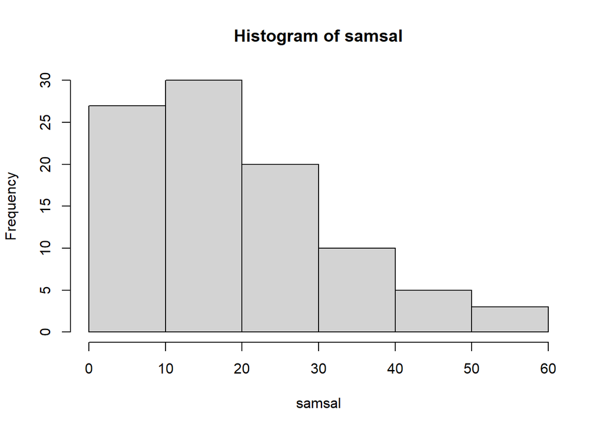

```r
k <- round(kurtosis(samsal),2)
hist(samsal)
```

تمرین دوم

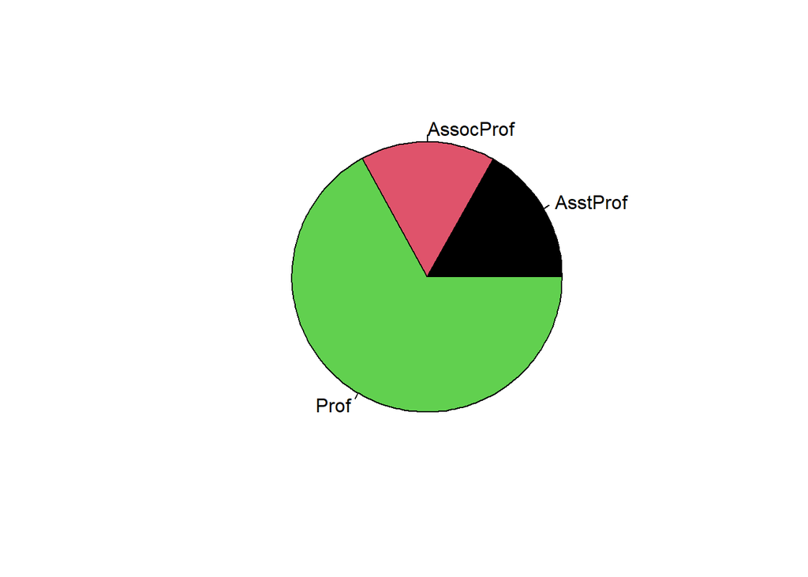

```r
t <- table(Salaries$rank)

pie(t, col = 9:12)
```

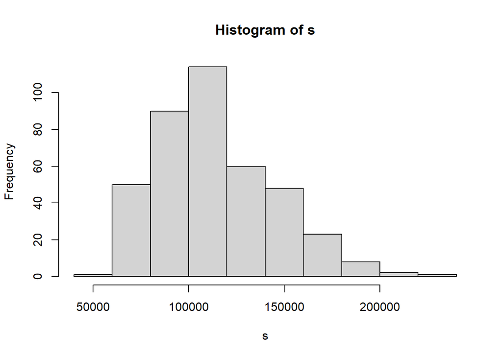

```r
s <- Salaries$salary
hist(s)
```

نمودار دایره ای برای داده ها کیفی و نمودار هیستوگرام برای داده های کمی است

تمرین سوم

```r
ro<- round(rnorm(100, 50, 10), 0)[round(rnorm(100, 50, 10), 0) %% 6 == 0]
ro
```

```
##  [1] 60 58 48 35 52 32 50 44 37 59 57 50 65 34 53
```

تمرین چهارم

```r
f <- function(x) {
  h <- length(x)
  harmonic_mean <-h / sum(1 / x)
  return(harmonic_mean)
}

f(Salaries$salary)
```

```
## [1] 106305.6
```

یک تابع برای محاسبه میانگین هارمونیک تعریف شده است و برای ستون salary اعمال شده است. میانگین هارمونیک برای مقایسه تأثیر مقادیر کوچک نسبت به بزرگ در محاسبات مفید است.

تمرین پنچم

```r
an <- function(x) {1 + (x^2)}
integrate(an, 1/2, 3)
```

```
## 11.45833 with absolute error < 1.3e-13
```

```r
an2 <- function(x,y) (x + (y^2) -1)
integral2(an2, 3,5,0,1)
```

```
## $Q
## [1] 6.666667
##
## $error
## [1] 6.661338e-16
```

در این تمرین، انتگرال یک تابع تک‌متغیره و یک تابع دوم‌متغیره محاسبه شده است. این کار برای بررسی نواحی زیر نمودارهای تابع در بازه‌های مشخص انجام می‌شود.

تمرین ششم

```r
a<- matrix(c(1,6,9,2,1,5,4,3,3), nrow = 3, ncol = 3)
a
```

```
##      [,1] [,2] [,3]
## [1,]    1    2    4
## [2,]    6    1    3
## [3,]    9    5    3
```

```r
det(a)
```

```
## [1] 90
```

```r
solve(a)
```

```
##            [,1]       [,2]        [,3]
## [1,] -0.1333333  0.1555556  0.02222222
## [2,]  0.1000000 -0.3666667  0.23333333
## [3,]  0.2333333  0.1444444 -0.12222222
```

```r
diag(a) <- 0
a
```

```
##      [,1] [,2] [,3]
## [1,]    0    2    4
## [2,]    6    0    3
## [3,]    9    5    0
```

یک ماتریس ۳×۳ تعریف و دترمینان و معکوس آن محاسبه شده است. سپس عناصر قطر اصلی صفر شده‌اند که نشان‌دهنده کار با ماتریس‌ها و عملیات خطی در R است